# **R notebook to analyse the HRV in Borderline Personality Disorder**

Estelle Thomas (with Copilot & Claude)

12 May, 2026, 08:45

*Estelle Thomas, Master 2 REHAB, Faculty of Medicine, Montpellier, France*

# 1 **Context scientific**

## 1.1 **Introduction**

Borderline Personality Disorder (BPD) is a severe, chronic, and disabling psychiatric condition characterized by instability of self-image, emotional dysregulation, unstable interpersonal relationships, and marked impulsivity, with a prevalence estimated at 2–6% in the general population and up to 20% in psychiatric settings (Ducasse et al., 2020). BPD is associated with high morbidity and mortality, partly driven by pathophysiological mechanisms involving HPA-axis hyperactivation, chronic low-grade inflammation, and autonomic nervous system dysregulation (Bozzatello et al., 2024).

Heart rate variability (HRV) serves as a non-invasive index of autonomic nervous system balance: higher resting HRV reflects greater parasympathetic (vagal) activity and better self-regulatory capacity, while reduced HRV signals sympathetic predominance and impaired emotion regulation (Thayer & Lane, 2000). A meta-analysis confirmed significantly lower resting-state vagally-mediated HRV in individuals with BPD compared to healthy controls (Koenig et al., 2016), supporting the hypothesis that autonomic dysfunction underlies the emotional instability characteristic of the disorder.

What I am looking for: I compare resting-state RMSSD between individuals with BPD and healthy controls as a psychophysiological marker of autonomic dysregulation.

## 1.2 **Aim**

The aim of this study is to examine whether resting-state heart rate variability (RMSSD) is significantly different between individuals with Borderline Personality Disorder and healthy controls.

## 1.3 **Method**

Each participant was equipped with a heart rate monitor (Polar H10) for 5 minutes at rest. RR intervals were recorded using the Elite HRV application. RMSSD was computed from these 5-minute resting RR interval recordings using NeuroKit2 (Makowski & al., 2021), in accordance with the standards established by the Task Force of the ESC and NASPE (1996).

## 1.4 **Participants**

- BPD patients (BPD): 32
- Healthy controls (CON): 23

## 1.5 **Outcome measure**

`HRV = RMSSD` (Root Mean Square of Successive Differences)

$RMSSD = \sqrt{\frac{1}{N-1} \sum_{i=1}^{N-1} (RR_{i+1} - RR_i)^2}$

*where $RR_i$ is the $i^{th}$ RR interval and $N$ is the total number of intervals.*

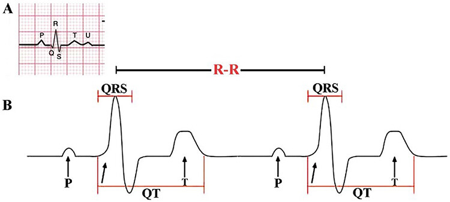

# 2 **Introduction**

## 2.1 **Objective**

The objective of this code is to analyze the Heart Rate Variability (HRV) data collected from participants with Borderline Personality Disorder (BPD) and a control group. The analysis will include descriptive statistics, comparisons between groups, and visualizations to understand the differences in HRV metrics between the two groups.

The scientific question to answer is : **Is resting-state heart rate variability (RMSSD) significantly different between individuals with Borderline Personality Disorder and healthy controls ?**

- **Dependent variable** : HRV metrics (e.g., RMSSD).
- **Independent variable** : Group (BPD vs Control).
- **Test** : I will use a non-parametric test such as the Mann-Whitney U test, because the effectif of this group is small and unbalanced.

## 2.2 **Hypothesis**

- **H0** (null hypothesis): There is no significant difference in resting-state RMSSD between individuals with BPD and healthy controls.
- **H1** (alternative hypothesis): Individuals with BPD exhibit significantly lower resting-state RMSSD compared to healthy controls, consistent with meta-analytic evidence (Koenig et al., 2016).

# 3 **Data organization**

**File:** `../Python_project/results/HRV_results.xlsx`

**Columns:**

- `ID` : pseudonymized participant identifier.
- `Group` : group of participant(BPD or CON).
- `HRV_RMSSD` : RMSSD value for each participant.

# 4 **Script organization**

- **Data loading and preparation** This section loads the HRV dataset.
- **Data cleaning** This section removes empty rows and duplicate entries.
- **Descriptive statistics by group** This section calculates mean, standard deviation, median, IQR, and n per group.
- **Visualization** This section produces a boxplot of RMSSD by group.
- **Normality test** This section applies the Shapiro-Wilk test to determine whether parametric or non-parametric testing is appropriate.
- **Statistical test: Mann-Whitney U test** This section performs the Mann-Whitney U test to compare RMSSD between groups.
- **Effect size: rank-biserial correlation** This section quantifies the magnitude of the group difference, independent of sample size.
- **Interpretation of results** This section prints an interpretation of the statistical output.

# 5 **R code**

## 5.1 **Data loading and preparation**

```r
# Install necessary libraries
# Comment lines if packages are already installed, please
#install.packages("readxl") # read the excel file
#install.packages("dplyr") # manipulate data frames
#install.packages("ggplot2") # for visualization

# load necessary libraries
library (readxl)
library(dplyr)
library(ggplot2)

# load dataset
hrv <- read_excel("../Python_project/results/HRV_results.xlsx")
```

## 5.2 **Cleaning and preparing data**

```r
# Suppress the empty line
hrv <- hrv %>%
  filter(!is.na(ID)) # Remove rows where ID is NA

# Suppress the dobble in hrv dataset (same ID and same group)
hrv <- hrv %>% distinct(ID, Group, .keep_all = TRUE)

head(hrv)
```

| ID | Group | HRV_RMSSD |
| --- | --- | --- |
| 10 | BPD | 88.115652 |
| 11 | BPD | 48.957069 |
| 12 | BPD | 8.625192 |
| 13 | BPD | 27.252732 |
| 14 | BPD | 12.454390 |
| 15 | BPD | 24.861691 |

## 5.3 **Descriptive statistics by groupe**

```r
hrv %>%
  group_by(Group) %>%
  summarise(
    mean_RMSSD = mean(HRV_RMSSD, na.rm = TRUE),
    sd_RMSSD = sd(HRV_RMSSD, na.rm = TRUE),
    median_RMSSD = median(HRV_RMSSD, na.rm = TRUE),
    IQR_RMSSD = IQR(HRV_RMSSD, na.rm = TRUE),
    n = n()
  )
```

| Group | mean_RMSSD | sd_RMSSD | median_RMSSD | IQR_RMSSD | n |
| --- | --- | --- | --- | --- | --- |
| BPD | 29.07190 | 20.35265 | 23.41620 | 20.63247 | 32 |
| CON | 42.47411 | 27.83353 | 36.42742 | 31.85546 | 23 |

## 5.4 **Visualization**

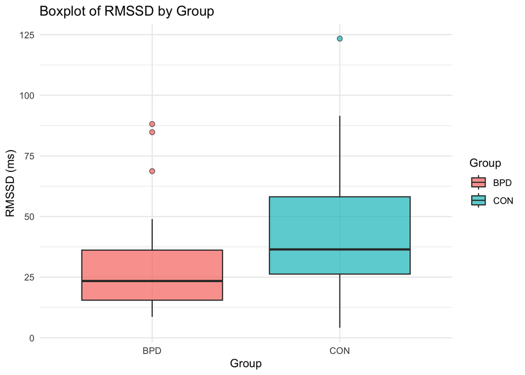

```r
# Boxplot HRV (RMSSD) by Group
ggplot(hrv, aes (x= Group, y= HRV_RMSSD, fill = Group)) +
  geom_boxplot(outlier.shape = 21, outlier.size = 2, alpha = 0.7) +
  labs(title = "Boxplot of RMSSD by Group",
       x = "Group",
       y = "RMSSD (ms)",
       color = "Group"
       )+
  theme_minimal()
```

```r
ggsave("results/boxplot_RMSSD_by_Group.png", width = 6, height = 4, dpi = 300)
```

## 5.5 **Normality test**

```r
# Normality test for RMSSD in each group
# Shapiro-Wilk test per group

shapiro_BPD<-shapiro.test(hrv$HRV_RMSSD[hrv$Group == "BPD"])
shapiro_CON<-shapiro.test(hrv$HRV_RMSSD[hrv$Group == "CON"])

if (shapiro_BPD$p.value > 0.05 & shapiro_CON$p.value > 0.05) {
  print("Both groups are normally distributed. I will use a Parametric test: t-test")
  t.test(HRV_RMSSD ~ Group, data = hrv)
} else {
  print("At least one group is not normally distributed. I will use a Non-parametric test: Mann-Whitney")
  wilcox.test(HRV_RMSSD ~ Group, data = hrv)
}
```

```
## [1] "At least one group is not normally distributed. I will use a Non-parametric test: Mann-Whitney"
```

```
##
##  Wilcoxon rank sum exact test
##
## data:  HRV_RMSSD by Group
## W = 246, p-value = 0.03741
## alternative hypothesis: true location shift is not equal to 0
```

## 5.6 **Statistical test : Mann-Whitney U test**

```r
results <-wilcox.test(HRV_RMSSD ~ Group, data = hrv)
print(results)
```

```
##
##  Wilcoxon rank sum exact test
##
## data:  HRV_RMSSD by Group
## W = 246, p-value = 0.03741
## alternative hypothesis: true location shift is not equal to 0
```

## 5.7 **Effect size: rank-biserial correlation**

```r
# Rank-biserial correlation r (effect size for Mann-Whitney)
# Interpretation: |r| < 0.3 = small, 0.3–0.5 = moderate, > 0.5 = large
n_BPD <- sum(hrv$Group == "BPD")
n_CON <- sum(hrv$Group == "CON")
r <- (results$statistic - (n_BPD * n_CON / 2)) / (n_BPD * n_CON / 2)
print(paste("Rank-biserial r =", round(r, 3)))
```

```
## [1] "Rank-biserial r = -0.332"
```

## 5.8 **Interpretation of results**

```r
if (results$p.value < 0.05) {
  print(paste0(
    "The difference in resting-state RMSSD between BPD and CON groups is statistically significant ",
    "(W = ", results$statistic, ", p = ", round(results$p.value, 3), ")."
  ))
} else {
  print(paste0(
    "The difference in resting-state RMSSD between BPD and CON groups is not statistically significant ",
    "(W = ", results$statistic, ", p = ", round(results$p.value, 3), ")."
  ))
}
```

```
## [1] "The difference in resting-state RMSSD between BPD and CON groups is statistically significant (W = 246, p = 0.037)."
```

# 6 **Discussion**

In this study, I compared resting-state RMSSD between individuals with Borderline Personality Disorder and healthy controls in order to explore autonomic nervous system functioning in BPD.

- The results showed **significantly lower RMSSD values in the BPD group compared to healthy controls (W = 246, p = 0.037)**, suggesting reduced parasympathetic activity in individuals with BPD.
- The rank-biserial correlation indicated a **moderate effect size (r = -0.332)**, supporting the presence of a meaningful group difference.

These **findings are consistent with previous literature reporting reduced vagally mediated heart rate variability in BPD populations** (Koenig et al., 2016). Reduced RMSSD may reflect alterations in autonomic regulation that contribute to emotional dysregulation and impulsivity commonly observed in BPD.

Although the sample size remains moderate and causal interpretations cannot be made, this study supports the relevance of HRV, and particularly RMSSD, as a potential psychophysiological marker associated with BPD.

# 7 **References**

Bozzatello, P., Marin, G., Gabriele, G., Brasso, C., Rocca, P., & Bellino, S. (2024). Metabolic dysfunctions, dysregulation of the autonomic nervous system, and echocardiographic parameters in borderline personality disorder: A narrative review. *International Journal of Molecular Sciences, 25*(22), 12286.

Ducasse, D., Lopez-Castroman, J., Dassa, D., Brand-Arpon, V., Dupuy-Maurin, K., Lacourt, L., & Olié, E. (2020). Exploring the boundaries between borderline personality disorder and suicidal behavior disorder. *European Archives of Psychiatry and Clinical Neuroscience, 270*, 959–967.

Koenig, J., Kemp, A. H., Feeling, N. R., Thayer, J. F., & Kaess, M. (2016). Resting state vagal tone in borderline personality disorder: A meta-analysis. *Progress in Neuro-Psychopharmacology and Biological Psychiatry, 64*, 18–26.

Makowski, D., Ben-Shachar, M. S., Pham, A. T., Lau, C., Brammer, M. J., & Chen, S. H. A. (2021). NeuroKit2: A Python toolbox for neurophysiological signal processing. *Behavior Research Methods, 53*, 1689–1696.

Task Force of the European Society of Cardiology and the North American Society of Pacing and Electrophysiology. (1996). Heart rate variability: Standards of measurement, physiological interpretation, and clinical use. *Circulation, 93*(5), 1043–1065.

Thayer, J. F., & Lane, R. D. (2000). A model of neurovisceral integration in emotion regulation and dysregulation. *Journal of Affective Disorders, 61*(3), 201–216.

Pham, T. and al. (2021). Heart Rate Variability in Psychology: A Review of HRV Indices and an Analysis Tool for the Meta-Analysis of Heart Rate Variability in Sleep and Memory. Sensors, 21(12), 3998. https://doi.org/10.3390/s21123998